# Pós-graduação em Ciências Veterinárias (IV/UFRRJ)

Análise Exploratória de Dados (AED) - Parte 2

Profa. Adriana Andrade (DEMAT/ICE/UFRRJ) Prof. Wagner Tassinari (DEMAT/ICE/UFRRJ)

2021

[figure not shown]

# Um pouco sobre a origem do ggplot

- A construção de gráficos no R foi revolucionada com a criação do pacote ggplot2, fruto da tese de doutorado de [Hadley Wickham](https://pt.vvikipedla.com/wiki/Hadley_Wickham) em 2008.
- O estatístico norte-americano [Leland Wilkinson](https://en.wikipedia.org/wiki/Leland_Wilkinson) em 2005, publicou o livro *The Grammar of graphics*, como uma fonte de princípios fundamentais para a construção de gráficos estatísticos. No livro, ele defende que um gráfico é o mapeamento dos dados a partir de atributos estéticos (posição, cor, forma, tamanho) de objetos geométricos (pontos, linhas, barras, caixas).
- A partir dessa definição, Hadley escreveu A [Layered Grammar of Graphics](https://cfss.uchicago.edu/notes/grammar-of-graphics/), sugerindo que os principais aspectos de um gráfico (dados, sistema de coordenadas, rótulos e anotações) podiam ser divididos em camadas, construídas uma a uma. Essa é a essência do ggplot2.
- Além de uma filosofia bem fundamentada, o ggplot2 ainda traz outras vantagens em relação aos gráficos do r base, como por exemplo os gráficos podem ser mais flexiveis e naturalmente mais bonitos. Tal estrutura acaba deixando o aprendizado muito mais intuitivo e é possível criar uma imensa gama de gráficos com poucas linhas de código.

# R base x ggplot2

| O pacote graphics | O pacote ggplot2 |
| --- | --- |
| Também chamado de R base | Fornece alternativas ao R base |
| Primeiro pacote gráfico do R e o mais usado. | Figuras construídas usando uma **gramática de gráficos** |

# GGPLOT: Grammar of Graphics

- **Dado:** o conjunto de dados que será usado
- **Estética:** variáveis e escalas para mapear o gráfico
- **Estatística:** representação estatística dos dados para melhor entendimento/visualização
- **Geometria:** elementos visuais usados no gráfico
- **Tema:** estilos cores aspectos gerais
- **Faceta:** múltiplos gráficos (sub painéis)
- **Coordenada:** representação espacial dos dados

# Tipos de variáveis

- **Univariadas**
  - Variável numérica (dispersão, histograma)
  - Variável categórica (gráfico de barras)
- **Bivariadas**
  - Numérica X numérica
  - Numérica X categórica
  - Categórica X categórica

# Prática

- Base de dados: daisy2.xlsx ([link](https://docs.google.com/spreadsheets/d/1wOVCA2Jk6bKMyvi84H602ftKRqdFq5Gw238_7dTMvJE/edit?usp=sharing))
- Conjunto de dados proveniente de um estudo tipo coorte a respeito das condições do manejo reprodutivo em rebanhos de bovinos leiteiros. O objetivo é avaliar o desempenho reprodutivo e a produção de leite desses animais.
- Dicionário de variáveis:

| Variáveis | Descrição | Tipo de Variáveis |
| --- | --- | --- |
| region | Regiões de estudo (1 a 4 regiões estudadas) | Categórica |
| herd | Identificador do rebanho | Contagem |
| cow | Identificador do animal | Contagem |
| study_lact | Lactação (Primeira ou segunda lactação no estudo) | Dicotômica |
| herd_size | Tamanho do rebanho | Contínua |
| mwp | Período de espera até a concepção | Contínua |
| parity | Número de lactações | Contagem |
| milk120 | Litros de leite nos primeiros 120 dias de lactação | Contínua |
| calv_dt | Data do parto | Data |
| cf | Intervalo parto/concepção ou *dias em aberto* | Contínua |
| fs | Concepção de primeira (1/0) | Dicotômica |
| cc | Intervalo do parto até a concepção | Contínua |
| wpc | Intervalo do período de espera atá a concepção | Contínua |
| spc | Serviços de concepção | Categórica |
| twin | Nascimento duplo (1/0) | Dicotômica |
| dyst | Complicações no parto (*Distocia fetal*) (1/0) | Dicotômica |
| rp | Retenção da placenta no parto (1/0) | Dicotômica |
| vag_disch | Corrimento vaginal observado (1/0) | Dicotômica |
| h7 | Indicador do subset do rebanho (1/0) | Dicotômica |

- Vamos supor que estamos interessados em estudar a relação entre **complicações no parto** em relação a algumas variáveis explicativas.
- Neste exemplo prático, vamos mostrar algumas técnicas de EAD para dados quantitativos e categóricos usando apenas algumas variáveis da base de dados daisy2.
- Serão escolhidas as variáveis:
  - **Variável de desfecho:** dyst
  - **Variáveis de explicativas:** mwp, parity, milk120, twin, rp, vag_disch

# Preparando o banco de dados

- Abra o banco de dados:

```r
library(readxl)
daisy2 <- read_excel("~/Google Drive/UFRRJ/Modelos Regressão 2021/Bancos/daisy2.xlsx")

daisy2 <- daisy2[daisy2$h7 == 1, ] # vamos apenas usar um subconjunto dos dados
```

Ou siga as seguintes etapas no RStudio: *Environment –> Import Dataset –> From Excel…*

- Selecione as variáveis para compor o banco que será trabalhado
  - *cow* - Identificador do animal
  - *dyst* - Complicações no parto (Distocia fetal)
  - *milk120* - Litros de leite nos primeiros 120 dias de lactação
  - *mwp* - Período de espera até a concepção
  - *parity* - Número de lactação
  - *twin* - Nascimento duplo
  - *rp* - Retenção da placenta no parto
  - *vag_disch* - Corrimento vaginal observado

```r
myvars <- c("cow", "dyst", "milk120", "mwp", "parity", "twin", "rp", "vag_disch")
banco <- daisy2[myvars]
```

# Estruturando o banco de dados

```r
# Colocando os labels nas variáveis categóricas

# Complicações no parto
banco$dyst <- factor(banco$dyst, labels = c("Nao", "Sim"))
banco$dyst <- relevel(banco$dyst, "Sim")

# Nascimento duplo
banco$twin <- factor(banco$twin, labels = c("Nao", "Sim"))
banco$twin <- relevel(banco$twin, "Sim")

# Retenção da placenta no parto
banco$rp <- factor(banco$rp, labels = c("Nao", "Sim"))
banco$rp <- relevel(banco$rp, "Sim")

# Corrimento vaginal observado
banco$vag_disch <- factor(banco$vag_disch, labels = c("Nao", "Sim"))
banco$vag_disch <- relevel(banco$vag_disch, "Sim")

# Categorizando a variável parity

banco$parity_cat <- cut((banco$parity), breaks = c(0, 1, 2, 4, Inf), labels = c("Até 1",
    "1 a 2", "2 a 4", "Mais de 4"))
```

# Filosofia do *ggplot*

- Chamando a biblioteca *ggplot2*

```r
# install.packages("ggplot2")
library(ggplot2)
```

- No ggplot2, os gráficos são construídos por camadas (ou, layers, em inglês), sendo a primeira delas dada pela função ggplot(). Essa função recebe um data frame e cria a camada base do gráfico. Se rodarmos apenas a função ggplot(), obteremos um painel em branco.

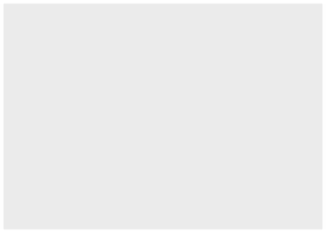

```r
g <- ggplot(data = banco)
g
```

- Apesar de termos passado os dados para a função, precisamos especificar como as observações serão mapeadas nos aspectos visuais do gráfico e quais formas geométricas serão utilizadas para isso. Cada camada do gráfico representará um tipo de mapeamento ou personalização. O código abaixo é um exemplo de um gráfico bem simples, construído a partir das duas principais camadas, com as variáveis **milk120** (Litros de leite nos primeiros 120 dias de lactação) e **parity** (Número de lactação).

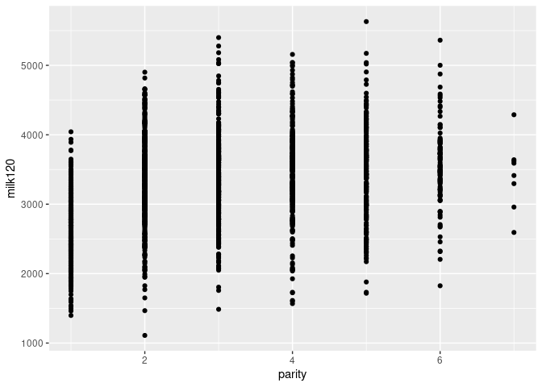

```r
g <- g + geom_point(mapping = aes(x = parity , y = milk120))
g
```

- No gráfico acima, a primeira camada é dada pela função ggplot() recebendo um *data frame*. A segunda camada é dada pela função geom_point(), especificando a forma geométrica utilizada no mapeamento das observações;
- As camadas são somadas com o sinal +, o mapeamento na função geom_point() recebe a função aes() (de *aesthetics*, estética em inglês), responsável por descrever como as variáveis serão mapeadas nos aspectos visuais da forma geométrica escolhida, no caso, pontos. A combinação da função ggplot() e de uma ou mais funções geom_() definirá o tipo de gráfico gerado.
- Podemos acrescentar uma terceira camada ao gráfico, agora com uma personalização. Repare como é simples acrescentar *labels* ao gráfico com a função labs().

```r
g <- g + labs(x = "Número de lactação", y = "Produção de leite (l)")
g
```

[output not shown]

- Ou podemos acrescentar os labels dos eixos como se fossem camadas distintas.

```r
g <- g + xlab("Número de lactação") + ylab("Produção de leite (l)")
g
```

[output not shown]

- A função aes() indica a relação entre os dados e cada aspecto visual do gráfico, como qual variável será representada no eixo $x$, qual será representada no eixo $y$, a cor e o tamanho dos componentes geométricos etc.
- Outro aspecto que pode ser mapeado nesse gráfico é a cor dos pontos sendo representado pela variável **dyst** (Complicações no parto).

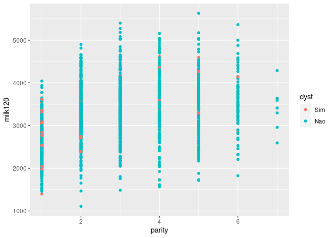

```r
ggplot(data = banco) +
  geom_point(mapping = aes(x = parity , y = milk120, color = dyst))
```

- Agora, a variável **mwp** (Período de espera até a concepção) será mapeada segundo à cor dos pontos, sendo representada na tonalidade da cor azul. Note que, por padrão, a legenda é inserida automaticamente ao gráfico.

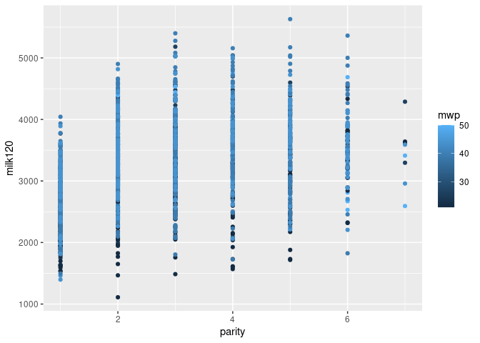

```r
ggplot(data = banco) +
  geom_point(mapping = aes(x = parity , y = milk120, color = mwp))
```

- Mudando a cor dos pontos:

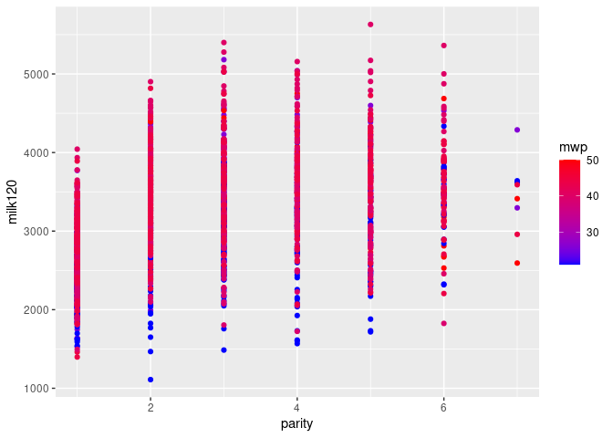

```r
ggplot(data = banco) +
  geom_point(mapping = aes(x = parity , y = milk120, color = mwp)) +
  scale_color_gradient(low="blue", high="red")
```

- Também podemos mapear o tamanho dos pontos a uma variável de interesse:

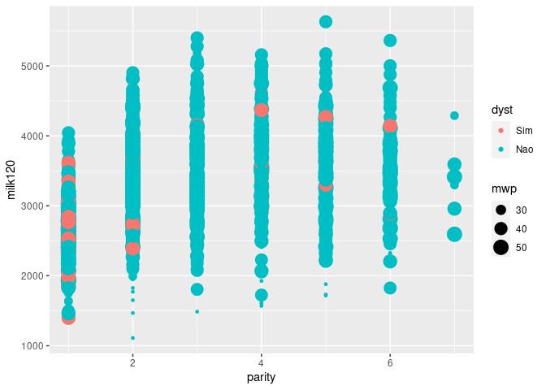

```r
ggplot(data = banco) +
  geom_point(mapping = aes(x = parity , y = milk120, color = dyst, size = mwp))
```

# Comparação R base x ggplot2

## Variável numérica univariada

### milk120 (rbase)

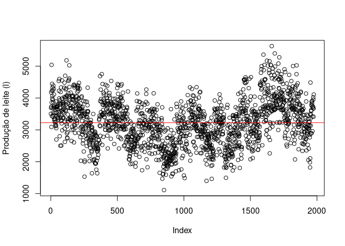

```r
plot(banco$milk120, xlab = "Index", ylab = "Produção de leite (l)")
abline(h = mean(banco$milk120, na.rm=T), col="red")
```

## milk120 (ggplot2)

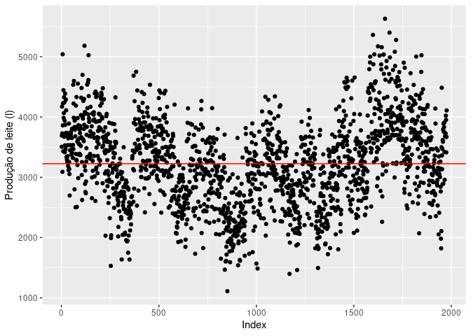

```r
p <- ggplot(aes(y=milk120, x=1:nrow(banco)), data = banco)
p <- p + geom_point() + xlab("Index") + ylab("Produção de leite (l)")
p + geom_hline(yintercept = mean(banco$milk120, na.rm=T), color = "red")
```

### Histograma: milk120 (rbase)

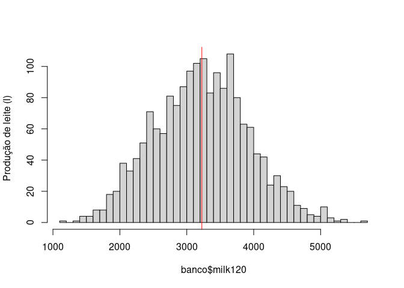

```r
hist( banco$milk120, ylab = "Produção de leite (l)", main = "", nclass = 50)
abline(v = mean(banco$milk120, na.rm=T), col="red")
```

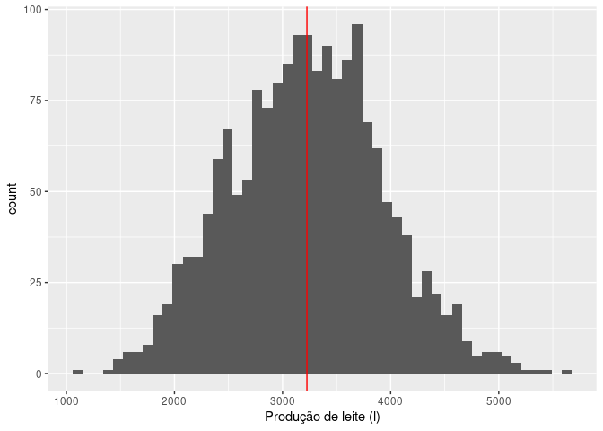

```r
p <- ggplot(banco, aes(x = milk120))
p <- p + geom_histogram(bins = 50)
p + geom_vline(xintercept = mean(banco$milk120, na.rm=T), color = "red") + xlab("Produção de leite (l)")
```

# Variável univariada categórica

### Variável parity categorizada: barplot (r base)

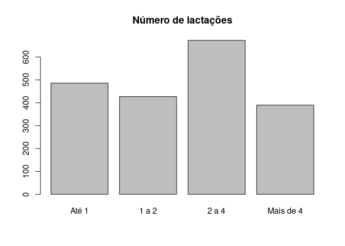

```r
tbl <- table(banco$parity_cat)
barplot(tbl, main = "Número de lactações")
```

### Variável parity categorizada: barplot (ggplot2)

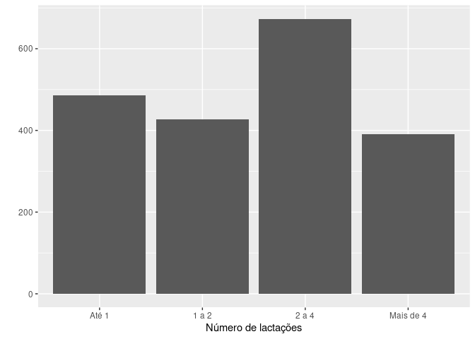

```r
p <- ggplot(banco, aes(x = parity_cat) )
p + geom_bar() + xlab("Número de lactações") + ylab("")
```

### Barplot horizontal + frequencia (r base)

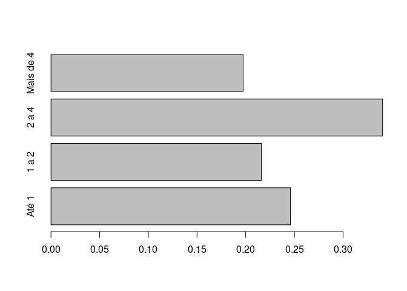

```r
barplot(prop.table(tbl), horiz = T)
```

### Barplot horizontal + frequencia (ggplot2)

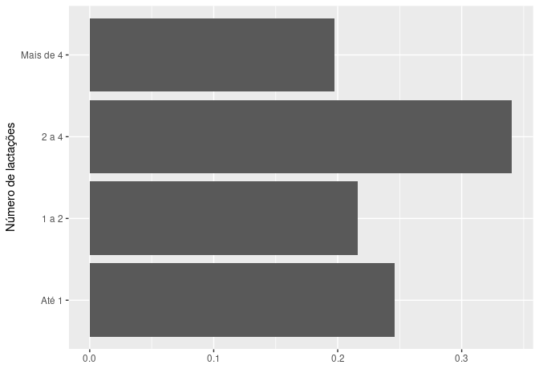

```r
p <- ggplot(banco, aes(x = parity_cat) )
p + geom_bar(aes(y=..count../sum(..count..))) +
  xlab("Número de lactações") + coord_flip() + ylab("")
```

# Bivariadas: variáveis numéricas

### milk120 x parity (r base)

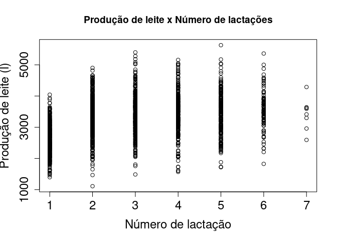

```r
plot(banco$parity, banco$milk120, xlab = "Número de lactação",
      ylab = "Produção de leite (l)", cex.lab = 1.5, cex.axis = 1.5)
title("Produção de leite x Número de lactações")
```

```r
p <- ggplot(banco, aes(x = parity, y = milk120) )
p + geom_point() + xlab("Número de lactação") + ylab("Produção de leite (l)")
```

[output not shown]

# Bivariadas: variável numérica x categórica

### milk120 x dyst: Histograma (r base)

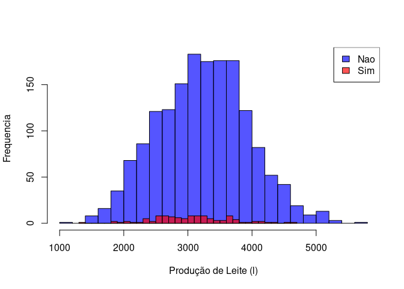

```r
# Gerando dois histogramas sobrepostos
hist(banco$milk120[banco$dyst == "Nao"], col=rgb(0,0,1,2/3), xlab = "Produção de Leite (l)", ylab = "Frequencia", main = "", nclass=30)  # first histogram
hist(banco$milk120[banco$dyst == "Sim"],
       col=rgb(1,0,0,2/3), add=T, nclass=30)
legend("topright", legend = c("Nao", "Sim"),
       fill = c(rgb(0,0,1,2/3), rgb(1,0,0,2/3)))
```

### milk120 x dyst: Histograma (ggplot2)

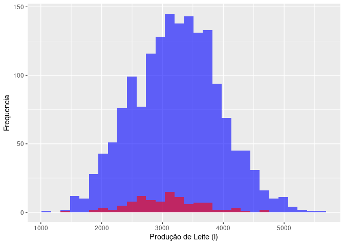

```r
ggplot(banco, aes(x = milk120)) +
    geom_histogram(bins = 30, data=subset(banco, dyst == "Nao"),fill = "blue", alpha = 0.6) +
    geom_histogram(bins = 30, data=subset(banco, dyst == "Sim"),fill = "red", , alpha = 0.6) +
    xlab("Produção de Leite (l)") + ylab("Frequencia")
```

### milk120 x dyst: Boxplot (r base)

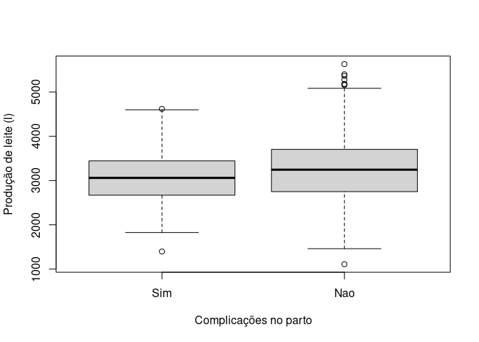

```r
boxplot(milk120 ~ dyst, data = banco, xlab = "Complicações no parto", ylab = "Produção de leite (l)", cex.lab = 1.0, cex.axis = 1.0)
```

### milk120 x dyst: Boxplot (ggplot2)

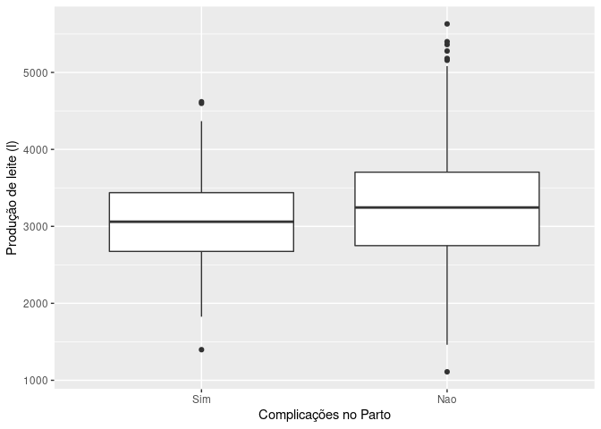

```r
p <- ggplot(banco, aes(y = milk120, x = dyst))
p  + geom_boxplot() + xlab("Complicações no Parto") +  ylab("Produção de leite (l)")
```

### milk120 x dyst x rp: Boxplot (ggplot2)

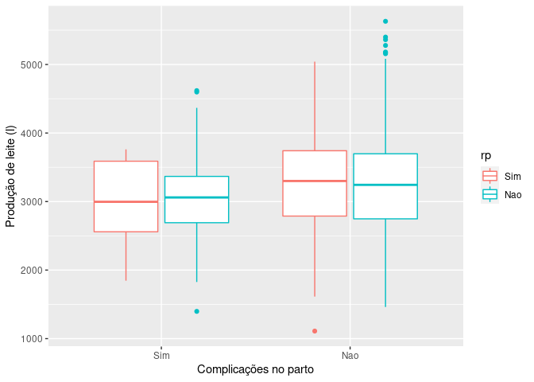

```r
p <- ggplot(banco, aes(y = milk120, x = dyst))
p + geom_boxplot(aes(color=rp)) + xlab("Complicações no parto") + ylab("Produção de leite (l)")
```

### milk120 x dyst x rp: Violin plot (ggplot2)

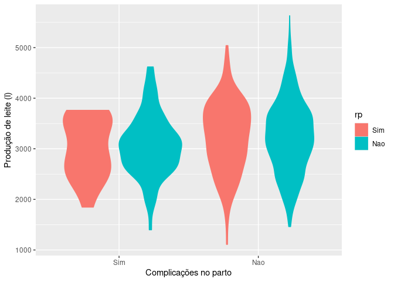

```r
p <- ggplot(banco, aes(y = milk120, x = dyst, fill=rp))
p + geom_violin(aes(color=rp)) + xlab("Complicações no parto") + ylab("Produção de leite (l)")
```

# Bivariadas: Variáveis categóricas

### parity_cat x dyst: barplot (r base)

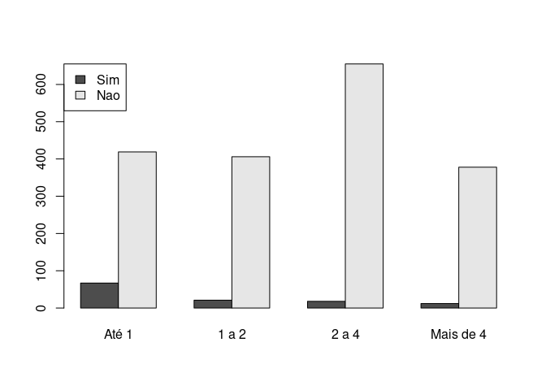

```r
tbl <- table(banco$dyst, banco$parity_cat)
barplot(tbl, legend.text = T, beside = T, args.legend =  list(x = "topleft") )
```

### parity_cat x dyst: barplot (ggplot2)

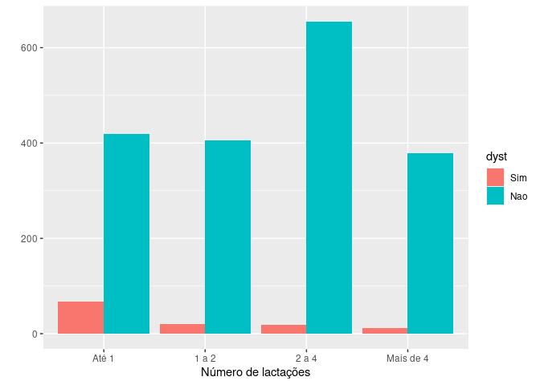

```r
p <- ggplot(banco, aes(x = parity_cat, fill = dyst) )
p + geom_bar(position='dodge') + xlab("Número de lactações") + ylab("")
```